# Midterm

# W5D12: Jan. 31st, 2022

## Ch. 9 - Isomorphism

In CH4, we made the operation table for a group $G_1=\{e,a,b,c\}$ of size 4 with the property $e^2=a^2=b^2=c^2=e$.

Another group of size 4 with this property is $G_2=\mathbb{Z}_2\times \mathbb{Z}_2$.

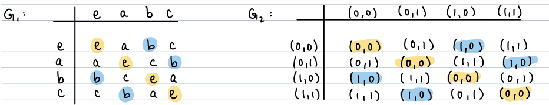

The function $f:G_1\rightarrow G_2$ given by

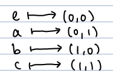

transforms the table for $G_1$ into the table for $G_2$. This function is called an $\underline{\text{isomorphism}}$ from $G_1$ to $G_2$.

An isopmorphism from a group $G_1$ to $G_2$ will have to be a bijection. What does it mean for $f$ to “transform” the table for $G_1$ into the table for $G_2$?

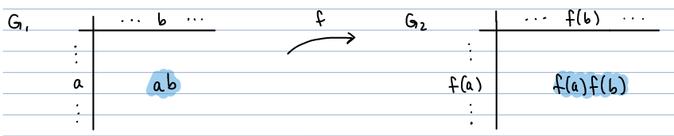

$\forall a,b,\in G$ we want f to take $ab\in G$ to the element $f(a)f(b)\in G_2$.

### Def. Isomorphism

A function $f:G_1\rightarrow G_2$ is called an $\underline{\text{isomorphism}}$ if f is a bijection and for all $a,b\in G$,
$$\text{operation in }G_1\rightarrow\quad f(ab)=f(a)f(b)\quad\leftarrow\text{operation in }G_2$$

If the operation in $G_1$ and / or $G_2$ is “+”, the above equation might look like $f(a+b)=f(a)f(b)$, $f(ab)=f(a)+f(b)$, or $f(a+b)=f(a)+f(b)$. (Left side might use addition, right side might use addition, both sides might use addition)

If f is an isomorphism from $G_1$ to $G_2$, we call $G_1$ and $G_2$ $\underline{\text{isomorphic}}$ and we write $G_1\cong G_2$.

### Ex. Show $\langle\mathbb{R},+\rangle\cong\langle\mathbb{R},\cdot\rangle$

I claim $f(x)=10^x$ is an isomorphism from $\mathbb{R}$ to $\mathbb{R}^+$.

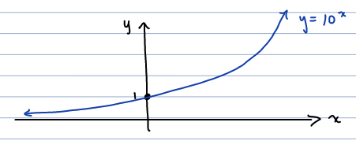

This is a bijection:

$$\begin{equation}\label{D121}
\begin{split}
f(x_1)=f(x_2) &\Rightarrow 10^{x_1}=10^{x_2}\\
&\Rightarrow log(10^{x_1})=log(10^{x_2})\\
&\Rightarrow x_1=x_2
\end{split}
\end{equation}$$

So, f is one-to-one.

Now let $y\in \mathbb{R}^+$ and $x=log(y)\in \mathbb{R}$. Then
$$f(x)=10^x=10^{log(y)}=y,$$

proving f is onto.

Last, take any $a,b\in\mathbb{R}$. Then
$$f(a+b)=10^{a+b}=10^a10^b=f(a)f(b)$$
.

Hence, $\langle\mathbb{R},+\rangle\cong\langle\mathbb{R},\cdot\rangle$.

### Ex. Show that $\langle\mathbb{Z},+\rangle\cong\langle7\mathbb{Z},+\rangle$

Note: Integers will always be under addition.

Recall, $7\mathbb{Z}=\{...,-14,-7, 0, 7, 14, 28, ...\}$

Define $f:\mathbb{Z}\rightarrow 7\mathbb{Z}$, by $f(n)=7n$. (You can check this is a bijection.)

Take $a,b\in \mathbb{Z}$, then
$$f(a+b)=7(a+b)=7a+yb=f(a)+f(b)$$

So $\mathbb{Z}\cong 7\mathbb{Z}$.

### Ex. Construct an isomorphism

Let $G_1=\mathbb{Z}_4=\{0,1,2,3\}=\langle 1\rangle$.

$\rightarrow$ all elements of $\mathbb{Z}_4$ can be obtained from 1 using repeated addition mod 4.

Let $G_2=\{1,-1,i,-i\}\subseteq\mathbb{C}$ with the operation of complex multiplication.

Since $i^2=-1$, $i^3=-i$, and $i^4=1$, then $G_2=\langle i\rangle$.

We’ll construct an isomorphism $f:G_1\rightarrow G_2$ by specifying that $f(1)=i$.

Then,

$$f(2)=f(1+1)=f(1)f(1)=i^2=-1$$

$$f(3)=f(1+2)=f(1)f(2)=i(-1)=-i$$

$$f(0)=f(1+3)=f(1)f(3)=i(-i)=1$$

(Note: $f(0)=f(2+2)=f(2)f(2)=(-1)(-1)=1$.)

So, we constructed an isomorphism $f:\mathbb{Z}_4\rightarrow G_2$:

$$f=(\begin{smallmatrix} 0 & 1 & 2 & 3\\ 1 & i & -1 & -i\end{smallmatrix})$$

Notice: 1 and 3 are inverses in $\mathbb{Z}_4$. Similarly, i and $-i$ are inverses in $G_2$.

(This is enough for cyclic groups)

Also Notice: Identity elements are always paired (0 paired with 1). Two inverses paired up in the first group will be paired up with the inverses in the second.

### Prop. 1: True for any isomorphic group

Let $f:G_1\rightarrow G_2$ be an isomorphism. Then

1. $f(e_1)=e_2$
2. $\forall a\in G$, $f(a)$ and $f(a^{-1})$ are inverses in $G_2$, i.e.
   $$f(a^{-1)}=[f(a)]^{-1}$$
3. If $G_1=\langle a\rangle$, then $G_2=\langle f(a)\rangle$.

### Proof of Prop. 1

1. Let $e_1$ and $e_2$ be the identites in $G_1$ and $G_2$, respectively. Then

$$\begin{equation}\label{D12,2}
\begin{split}
f(e_1)e_2 &= f(e_1)\\
&= f(e_1e_1)\\
&= f(e_1)f(e_1)\quad\text{since f is an isomorphism}
\end{split}
\end{equation}$$

$\Rightarrow e_2=f(e_1)$, by left cancellation.

2. To show $f(a)$ and $f(a^{-1})$ are inverses, let’s show their product is the identity $e_2\in G$:

$$\begin{equation}\label{12,3}
\begin{split}
f(a)f(a^{-1}) &= f(aa^{-1})\\
&=f(e_1)\\
&= e_2\quad\text{ by part(i)}
\end{split}
\end{equation}$$

Therefore, $f(a^{-1})=(f(a))^{-1}$ by Theorem 2 from Ch. 4.

# W5D13: Feb. 2nd, 2022

## Ch. 9 - Isomorphism

A function $f:G_1\rightarrow G_2$ is called an $\underline{\text{isomorphism}}$ if f is a bijection and for all $a,b\in G$,
$$f(ab)=f(a)f(b).$$

### Ex. Show matrix $G\cong \langle \mathbb{Z},+\rangle$

Let $G\{(\begin{smallmatrix} 1 & n \\ 0 & 1\end{smallmatrix})|n\in \mathbb{Z}\}$ with the operation of matrix multiplication. Let’s show $G\cong \langle \mathbb{Z},+\rangle$.

First, why is G a group?

1. identity = $(\begin{smallmatrix} 1 & 0 \\ 0 & 1\end{smallmatrix})\in G$
2. $(\begin{smallmatrix} 1 & a \\ 0 & 1\end{smallmatrix})(\begin{smallmatrix} 1 & b \\ 0 & 1\end{smallmatrix})=(\begin{smallmatrix} 1\cdot 1 + a\cdot 0 & 1\cdot b+a\cdot 1 \\ 0\cdot 1+1\cdot 0 & 0\cdot b+1\cdot 1\end{smallmatrix})=(\begin{smallmatrix} 1 & a+b \\ 0 & 1\end{smallmatrix})\in G$.
3. $(\begin{smallmatrix} 1 & a \\ 0 & 1\end{smallmatrix})^{-1}=(\begin{smallmatrix} 1 & -a \\ 0 & 1\end{smallmatrix})\in G$

Now let’s show $G\cong\mathbb{Z}$. Define $f:\mathbb{Z}\rightarrow G$ by
$$f(n)=(\begin{smallmatrix} 1 & n \\ 0 & 1\end{smallmatrix}).$$

One-to-one:

Suppose $f(n_1)=f(n_2)$ for some $n_1,n_2\in\mathbb{Z}$. Then
$$(\begin{smallmatrix} 1 & n_1 \\ 0 & 1\end{smallmatrix})=(\begin{smallmatrix} 1 & n_2 \\ 0 & 1\end{smallmatrix})\quad\Rightarrow\quad n_1=n_2.$$

Onto:

Take any $(\begin{smallmatrix} 1 & n \\ 0 & 1\end{smallmatrix})\in G$. Then $n\in\mathbb{Z}$ and $f(n)=(\begin{smallmatrix} 1 & n \\ 0 & 1\end{smallmatrix})$. Take any $a,b\in\mathbb{Z}$. Then
$$f(a+b)=(\begin{smallmatrix} 1 & a+b \\ 0 & 1\end{smallmatrix})=(\begin{smallmatrix} 1 & a \\ 0 & 1\end{smallmatrix})(\begin{smallmatrix} 1 & b \\ 0 & 1\end{smallmatrix})=f(a)f(b).$$

### Groups that are isomorphic have the same algebraic properties

Suppose that $G_1\cong G_2$. Then

1. $|G_1|=|G_2|$ (they have the same size)
2. $G_1$ is abelian if and only if $G_2$ is abelian.
3. $G_1$ is cyclic if and only if $G_2$ is cyclic.
4. $G_1$ has the property that every element squared equals e if and only if $G_2$ has the same property.
5. Every subgroup of $G_1$ is isomorphic to a subgroup of $G_2$.

$\vdots$

### Ex. $\mathbb{Z}_4\ncong \mathbb{Z}_2\times \mathbb{Z}_2$

Show that $\mathbb{Z}_4=\{0,1,2,3\}$ is not isomorphic to $\mathbb{Z}_2\times \mathbb{Z}_2$.

The group $\mathbb{Z}_4\langle 1\rangle$ is cyclic. The group $\mathbb{Z}_2\times \mathbb{Z}_2$ is not, since

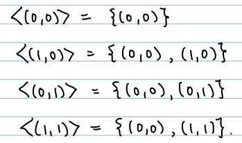

Another way to show $\mathbb{Z}_4\ncong \mathbb{Z}_2\times \mathbb{Z}_2$:

$\mathbb{Z}_2\times \mathbb{Z}_2$ has the property that every element added to itself is the identity. The group $\mathbb{Z}_4$ doesn’t have this property:

$$1+1=2\ne 0\in \mathbb{Z}_4$$

$\underline{\text{Fact}}$: (We’ll prove this in ch. 11): Every group of size 4 is isomorphic to $\mathbb{Z}_4$ or $\mathbb{Z}_2\times\mathbb{Z}_2$. (This is either one or the other since we just showed these are not isomorphic to each other)

Let G be the group of symmetries of a (non-square) rectangle. Then $G=\{1,R,S_1,S_2\}$:

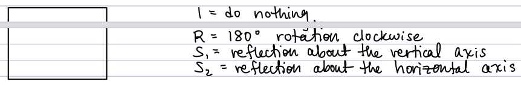

Any element of G times itself is the identity, so $G\cong \mathbb{Z}_2\times \mathbb{Z}_2$.

We could also show that this isn’t cyclic so it wouldn’t be in $\mathbb{Z}_4$, so therefore it is isomorphic to $\mathbb{Z}_2\times\mathbb{Z}_2$ (by fact above).

### Ex. Show $\langle \mathbb{R},+\rangle \ncong \langle \mathbb{R}^*,\cdot\rangle$

The group $\mathbb{R}^*$ has a cyclic subgroup of size 2: $\langle -1\rangle =\{1,-1\}$.

The group $\mathbb{R}$ does not have a cyclic subgroup of size 2. The only finite cyclic subgroup of $\mathbb{R}$ is $\langle 0\rangle =\{0\}$, since $a\ne 0$,
$$\langle a\rangle =\{...,-2a,-a,0,a,2a,3a,...\},$$

which is infinite.

Alternatively, $\langle \mathbb{R}^*, \cdot \rangle$ has two elements that are their own inverse (1 and $-1$). In $\langle \mathbb{R}^*, + \rangle$ there is only one element that is its own inverse (the identity 0).

### Ex. Show $\langle\mathbb{C}^*,\cdot\rangle\ncong\langle \mathbb{R}^*,\cdot\rangle$

The group $\mathbb{C}^*$ has a cyclic subgroup of size 4: $\langle i\rangle=\{1,-1,i,-i\}$ but $\mathbb{R}^*$ doesn’t have a subgroup of size 4.

$$\begin{equation}\label{D13}
\begin{split}
f((a_1+b_1i)+(a_2+b_2i)) &= f(a_1+a_2+(b_1+b_2)i)\\
&= (a_1+a_2,b_1+b_2)\\
&= (a_1,b_1) + (a_2,b_2)\\
&= f(a_1+b_1i)+f(a_2+b_2i)
\end{split}
\end{equation}$$

### Cayley’s Theorem (1854)

Every group is isomorphic to a permutation group. (Like $S_4, $S_5$ …)

$\underline{\text{Proof}}$: Let G be any group. For every $a\in G$, define a function $f_a:G\rightarrow G$ by
$$f_a(x)=ax.$$

Let $H=\{F_a|a\in G\}$. We’ll show that H is a subgroup of $S_G$ (all permutations of G), and that $G\cong H$.

In Hw 2, you showed:

1. Each function $f_a$ is a bijection, i.e. $H\subseteq S_G$.
2. $f_a\circ f_b=f_{ab}$, i.e. H is closed under composition.
3. $(f_a)^{-1}=f_{a^{-1}}$, i.e. H is closed under inverses.

Note that $f_e$, “left multiplication by e”, is the identity permutation, since
$$f_e(x)=ex=x=\epsilon(x).$$

So H contains the identity permmutation. Hence, $H\leq S_G$, i.e. H is a permutation group.

Now let’s show that $G\cong H$. Define a function $\alpha:G\rightarrow H$ by
$$\alpha(a)=f_a.$$

Then $\forall a,b\in G$,
$$\alpha(ab)=f_{ab}=f_a\circ f_b=\alpha(a)\circ\alpha(b).$$

(See the book for the proof that $\alpha$ is a bijection.) Hence, $\alpha$ is an isomorphism, proving $G\cong H$. $\quad\quad\square$

# W5D14: Feb. 4th, 2022

One more example from CH9:

### Ex. Show $G_2$ also has same property as $G_1$

Suppose $G_1\cong G_2$ and that $G_1$ has the property that every element squared equals the identity $e_1$. Show $G_2$ must also have this property.

$\underline{\text{Proof}}$:

Since $G_1\cong G_2$ there is an isormorphism $f:G_1\rightarrow G_2$.

Take any $y\in G_2$. (We want to show $y^2=e_2$.)

Since f is onto, there exists $x\in G_1$, such that $f(x)=y$.

Hence,

$$\begin{equation}\label{D14e1}
\begin{split}
y^2=(f(x))^2 &= f(x)f(x)\\
&= f(xx)\quad\quad\text{, since f is an isomorphism}\\
&= f(x^2)\\
&= f(e_1)\quad\quad\text{, since the square of every element of G, equals e}\\
&= e_2
\end{split}
\end{equation}$$

$\Rightarrow$ Every element of $G_2$ squared equales the identity. $\quad\quad\square$

“isomorphisms take the identity (e) from the first group to the second group.”

## Ch. 10 - The Order of Group Elements

- not on HW or the midterm
- “ordr is related to a size but the two are different things”

Let G be a group and let $a\in G$. For any $n>0$

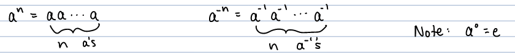

### Exponent Laws for Groups

For all $m,n\in \mathbb{Z}$,

1. $a^{m+n}=a^ma^n$
2. $a^{mn}=(a^m)^n$
3. $a^{-n}=(a^{-1})^n=(a^n)^{-1}$

The exponent law we can’t necessarily use: $(ab)^n=a^nb^n$.

### Def. Order

Let $a\in G$. The $\underline{\text{order}}$ of a, denoted $ord(a)$ or $|a|$, is the least positive integer n such that
$$a^n=e.$$

If $a^n\ne e$ for all poisitve integers n, we say $ord(a)=\infty$.

Let’s rewrite the definition using +:

$ord(a)$ is the least positive $n\in\mathbb{Z}$ such that

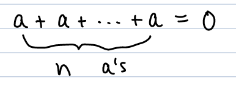

### Ex. Find the orders of all elements of $\mathbb{Z}_6=\{0,1,2,3,4,5\}.$

- Additive
- “How many a’s do you need to add together to get 6.”
- “For four you are finding a multiple of six, which is why it’s ord(4)=3 since 4+4+4=0.”
- “Multiples of 6 work for the integers”

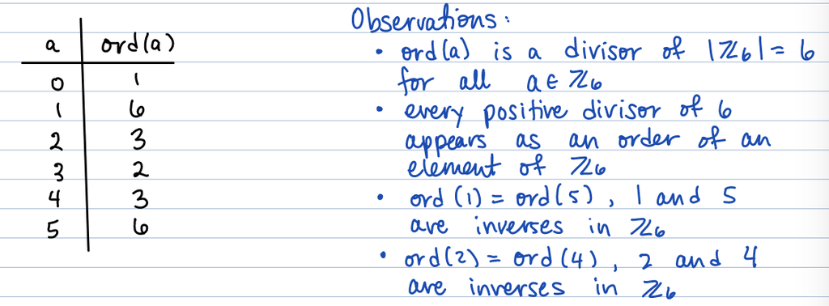

$\underline{\text{Comment}}$: Supppose every element of G squared equals the identity. This is equivalent to saying that every non-identity element of G has order 2.

### 10 Examples

1. Whats the order of 12 in $\mathbb{Z}_{20}$?

We need a sum of 12’s that is a multiple of 20. The least common multiple (lcm) of 12 and 20 is 60. We need to add 5 to 12’s to get 60, so
$$ord(12)=\frac{lcm(12,20)}{12}=\frac{60}{12}=5$$

2. If $k\in \mathbb{Z}_n=\{0,1,2,...,n-1\}$ is nonzero,
   $$ord(k)=\frac{lcm(k,n)}{k}.$$
3. Find the order of $f=(132)\in S_3$.

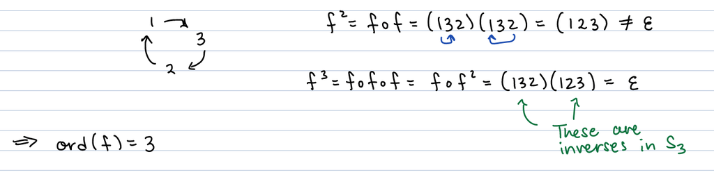

- “To compose these cycles start are the right with 1. 1 goes to three and then three goes to two, so 1 goes to 2. Starting on the right again, 2 goes to 1 which goes to three. So 2 goes to three.”
4. Find the order of $g=(125786)\in S_8$.

The order of a cycle in $S_n$ is equal to its length. So,
$$ord(g)=6.$$

- “Notice the previous example has 3 elements, and 3 arrows.”
- “We would get six different things until $f^6$”
5. Whats the order of $h=(14)(2356)\in S_6$?

For any $n>0$,

$$\begin{equation}\label{D14e5}
\begin{split}
h^n=[(14)(2356)]^n &= (14)(2356)(14)(2356)...(14)(2356)\\
&= (14)^n(2356)^n\quad\quad\text{, since disjoint cycles commute}
\end{split}
\end{equation}$$

We need n to be a multiple of 2 so that $(14)^n=\epsilon$.

We need n to be a multiple of 4 so that $(2356)^n=\epsilon$.

Since $4=lcm(2,4)$, the order of $h=(14)(2356)$ is 4.

6. The order of a composition of **disjoint** cycles in $S_n$ is the lcm of the lengths of the cycles.
   $$\text{Ex:}\quad ord((2364)(157))=lcm(4,3)=12$$
7. The group $S_4$ has no elements of order 6 (even though 6 is a divisor of $|S_4|=24$).

Since $S_4$ is the group of permutations of $\{1,2,3,4\}$ it has no cycles of length 6.

Similarly, no element of $S_4$ can be written as a composition of two disjoint cycles with lengths 2 and 3.

8. What is the order of $(4,8)\in\mathbb{Z}_6\times\mathbb{Z}_{12}$?

We need to add three 4’s to get 0 in $\mathbb{Z}_6$. Similarly,

we need to add three 8’s to get 0 in $\mathbb{Z}_{12}$.

So, $(4,8)+(4,8)+(4,8)=(4+4+4,8+8+8)=(0,0)$

$\Rightarrow ord((4,8))=3$.

9. What is the order of $(4,6)\in \mathbb{Z}_6\times\mathbb{Z}_{12}$?

We need to add two 6’s to get 0 in $\mathbb{Z}_{12}$. Since we need to add three 4’s to get 0 in $\mathbb{Z}_6$,

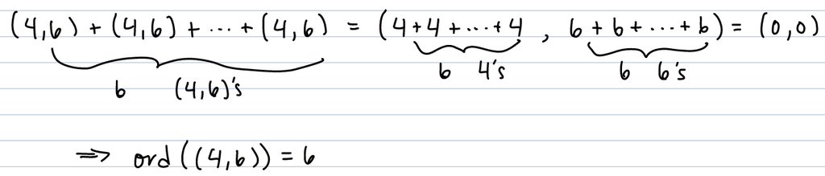

10. In $G\times H$, the order of (g,h) is
    $$lcm (ord(g),ord(h))$$
    .

# W6D15: Feb. 7th, 2022

## Ch. 10 Continued

The $\underline{\text{order}}$ of an element a in a group G is the least positive integer n such that $a^n=e$ (or a+a+a…(for n a’s)…+a=0) if the operation is +).

If no such $n>0$ exists, we say the order of a is $\infty$.

### Ex. In $\mathbb{Z}$, ord(1)=$\infty$

Because no sum of 1’s is equal to 0.

### Ex. Suppose $a\in G$ has order 4.

(Then $a^4=e$ and none of a,$a^2$, or $a^3$ equal e.)

Consider $a^{19}\in G$. Then

$$\begin{equation}\label{D15e1}
\begin{split}
a^{19}=a^{4\cdot 4+3}&=(a^4)^4a^3\\
&= e^4a^3\quad\quad\text{, since }a^4=e\\
&=a^3\quad\quad\text{, since }e^4=e
\end{split}
\end{equation}$$

Similarly,

$$\begin{equation}\label{D15e1.2}
\begin{split}
a^{-10} = a^{4(-3)+2} &= (a^4)^{-3}a^2\\
&= e^{-3}a^2\quad\quad\text{, since }a^4=e\\
&= a^2\quad\quad\text{, since } e^{-3}=e.
\end{split}
\end{equation}$$

### The Division Algorithm

Let m,n $\in\mathbb{Z}$ and $n>0$. Then there exists q (quotient),r (remainder) $\in \mathbb{Z}$ such that
$$\frac{m}{n}=q+\frac{r}{n}\quad\quad\text{and}\quad\quad0\leq\frac{r}{n}<1$$

$$\Leftrightarrow m=nq+r\quad\quad\text{and}\quad\quad0\leq r<n.$$

### Ex. Suppose ord(b)=7. Rewrite the element $b^{26}$.

Using the Division Algorithm,

$26=7\cdot 3+5$

$\Rightarrow b^{26}=b^{7\cdot 3+5}=(b^7)^3b^5=e^3b^5=b^5$.

### Theorem 3

Let G be a group and let $a\in G$ have order $n<\infty$. Then every power of a is equal to exactly one
$$e,a,a^2,a^3,...,a^{n-1}.$$

$\underline{\text{Proof}}$:

Lets see why $e,a,a^2,a^3,...,a^{n-1}$ are distinct elements.

Suppose that $a^i=a^j$ for some $0\leq i\leq j\leq n-1.$

$$\begin{equation}\label{d15prooft3}
\begin{split}
a^i=a^j &\Rightarrow a^ja^{-i}=a^ja^{-i}\\
&\Rightarrow e=a^{j-i}.
\end{split}
\end{equation}$$

Since $0<j-i<n$, the fact that $a^{j-i}=e$ contradicts that ord(a)=n is the $\underline{\text{least}}$ positive integer such that $a^n=e$.

(n should be the smallest value in order, but we just showed j-i exists and is smaller than n)

Therefore, the elements $e,a,a^2,...,a^{n-1}$ are distinct.

Now take any element $a^m$. By the Division Algorithm $\exists$ q,r $\in \mathbb{Z}$ such that $m=nq+r$ and $0\leq r<n$. So,
$$a^m=a^{nq+r}=(a^n)^qa^r=e^qa^r=a^r.$$

Since $0\leq r< n$, $a^r$ is one of e, a, $a^2$, …, $a^{n-1}$.

### Corollary

Let ord(a)=n<$\infty$. Then the cyclic group gemerated by a has n elements:

$$\begin{equation}\label{d15ex3}
\begin{split}
\langle a\rangle &=\{..., a^{-2}, a^{-1}, e, a, a^2, a^3\}\\
&= \{e,a,a^2,...,a^{n-1}\}.
\end{split}
\end{equation}$$

### Theorem 4

Let ord(a)=$\infty$. Then for all i,j $\in\mathbb{Z}$, if $i\in j$ then $a^i\ne a^j$.

(no power of a gives us the identity, and no power of a is the same)

$\underline{\text{Proof}}$:

Suppose $a^i=a^j$ for some $i<j$. Then $a^{j-i}=e$.

Since $j-i\ne 0$, this contradicts that ord(a)=$\infty$. Hence if $i\ne j$, then $a^i\ne a^j$.

### Corollary

If ord(a)=$\infty$, the cyclic group generated by a has infinitely many elements:
$$\langle a\rangle =\{...,a^{-2},a^{-1},e,a,a^2\}$$

### Ex. Suppose $a\in G$ has order 6. What other powers of a are equal to e?

Suppose $a\in G$ has order 6. (Then $a^6=e$ and none of a, $a^2$, $a^3$, $a^4$, $a^5$ equals e.)

What other powers of a are equal to e? We need the exponent to be a multiple of 6. For example,
$$a^{-24}=a^{6(-4)}=(a^6)^{-4}=e^{-4}=e.$$

### Theorem 5

Let $a\in G$ have order $n<\infty$. Then $a^m=e$ if and only if m is a multiple of n.

$\underline{\text{Proof}}$:

($\Leftarrow$) Suppose m is a multiple of n. Then $m=nq$ for some $q\in \mathbb{Z}$. Hence,
$$a^m=a^{nq}=(a^n)^q=e^q=e.$$

$\Rightarrow$ Now suppose that $a^m=e$. By the Division Algorithm, we can write
$$m=nq+r,$$
where $0\leq r< n$. Therefore,

$$\begin{equation}\label{d1prooft5}
\begin{split}
a^m=e &\Rightarrow a^{nq+r}=e\\
&\Rightarrow (a^n)^qa^r=e\\
&\Rightarrow a^r=e\quad\quad\text{, since }a^n=e.
\end{split}
\end{equation}$$

Since $0\leq r<n$ and ord(a)=n, it must be the case that $r=0$. Thus,
$$m=nq+0=nq,$$
i.e. m is a multiple of n.

### Examples of proofs about order

(Using Th. 5)

1. Suppose ord(a)=$n<\infty$. Show ord($a^{-1}$)=n as well.

$\underline{\text{Proof}}$: Since $a^n=e$,
$$(a^{-1})^n=(a^n)^{-1}=e^{-1}=e.$$

Thus, by Theorem 5, n is a multiple of ord($a^{-1}$)

Let m=ord($a^{-1}$). Then
$$a^m=((a^{-1})^m)^{-1}=e^{-1}=e.$$

So, by Theorem 5, m is a multiple or ord(a)=n.

We have that n is a multiple of m and vice-versa. Since m and n are positive integers, this implies m=n, i.e.
$$\text{ord(a)}=\text{ord}(a^{-1}).$$

2. Let $f:G_1\rightarrow G_2$ be an isomorphism. Suppose $a\in G$, has order 3. Prove $f(a)\in G_2$ has order 3.

$\underline{\text{Proof}}$:

$$\begin{equation}\label{d15p2}
\begin{split}
f(a)^3 &= f(a)f(a)f(a)\\
&= f(a^2)f(a)\quad\quad\text{, since f is an isomorphism}\\
&= f(a^3)\quad\quad\text{, since f is an isomorphism}\\
&= f(e_1)\\
&= e_2
\end{split}
\end{equation}$$

Note: we showed $f(e_1)=e_2$ in class.

Since ord(a)=3, neither a nor $a^2$ equal $e_1$. So, because f is one-to-one, neither f(a) nor f($a^2$) equals $e_2$.

$$\Rightarrow f(a)\ne e_2\quad\quad\text{and}\quad\quad f(a)^2=f(a^2)\ne e_2.$$

Hence, by definition, ord(f(a))=3.

## Ch. 11 Cyclic Groups

If ord(a)=$n<\infty$, then

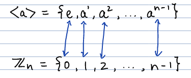

The groups $\langle a\rangle$ and $\mathbb{Z}_n$ are isomorphic. The function $f:\langle a\rangle\rightarrow\mathbb{Z}_n$ defined by
$$f(a^i)=i$$
is an isomorphism:
$$f(a^ia^j)=f(a^{i+j})=i+j=f(a^i)+f(a^j).$$

Will do Review on Wednesday!

# W6D16: Feb. 9th, 2022

## MTH 344 Midterm

- Friday February 11th, 11:30-12:35 in person
- covers chapters 2-9
- 5 questions
- no notes / book allowed (this means more partial credit)
- you will write your solutions on a separate paper. I will bring blank white paper to the exam. If you prefer to use your own paper that’s okay.

### Topics

- Ch 2-3: Definition of a group (associative, identity, inverses)
- Ch 4: Cancellation Law, $(ab)^{-1}=b^{-1}a^{-1}$, $(a^{-1})^{-1}=a$
- Ch 5: Subgroups
- Ch 7-8: Permutations in $S_n$, cycle notation, even/ odd permutations
- Ch 9: Isomorphisms

### HW 3 #5

Isomorphic to $\mathbb{Z}_2\times\mathbb{Z}_2$ or $\mathbb{Z_}_4$?

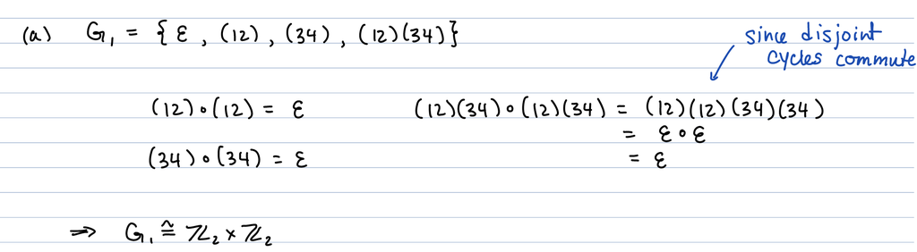

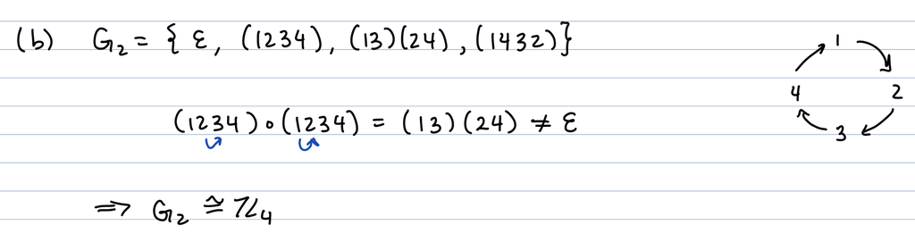

### HW 3 #5

$f:G_1\rightarrow G_2$ isomorphsim, H is a subgroup of $G_1$.

Show $f(H)=\{f(h)|h\in H\}$ is a subgroup of $G_2$.

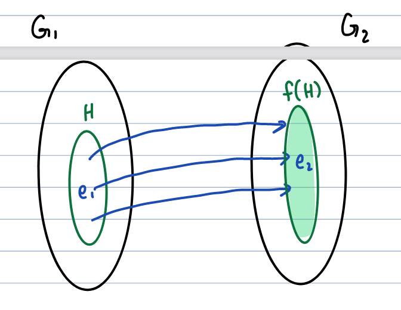

1. Show $e_2\in f(H)$

We know $e_1\in H$ since H is a subgroup. Since $e_2=f(e_1)$, $e_2\in f(H)$.

2. Let a,b $\in f(H)$. Show $ab^{-1}\in f(H)$.

This means $a=f(h_1)$ and $b=f(h_2)$ for some $h_1,h_2\in H$.

$$\begin{equation}\label{D16 HW3ii}
\begin{split}
\Rightarrow ab^{-1} &= f(h_1)f(h_2)^{-1}\\
&= f(h_1)f(h_2^{-1})\\
&= f(h_1h_2)\quad\quad\text{, since f is an isomorphism}
\end{split}
\end{equation}$$

Since H is a subgroup of G, $h_1h_2^{-1}\in H$. So $ab^{-1}=f(h_1h_2^{-1})\in f(H)$.

## Practice Problems

2. Let G be a group and a,b,c, x $\in G$. Solve
   $$cx^2b=a\quad\quad\text{ and }\quad\quad x^3=e$$
   for x in terms of a, b, and c.

$$\begin{equation}\label{pp2}
\begin{split}
cx^2b=a &\Rightarrow cx^2bb^{-1}=ab^{-1}\\
&\Rightarrow cx^2=ab^{-1}\\
&\Rightarrow cx^3=ab^{-1}x\\
&\Rightarrow c=ab^{-1}x\quad\quad\text{, because }x^3=e\\
&\Rightarrow a^{-1}c=a^{-1}ab^{-1}x\\
&\Rightarrow a^{-1}c=b^{-1}x\\
&\Rightarrow ba^{-1}c=bb^{-1}x\\
&\Rightarrow x=ba^{-1}c
\end{split}
\end{equation}$$

4. G is abelian group. Show $H=\{x\in G|x=g^2\text{ for some } g\in G\}$ is a subgroup of G.
1. Show $e\in H$.

Since $e\in H$. Since $e=e^2$, $e\in H$.

2. Let a,b $\in H$. Show $ab^{-1}\in H$.

This means $a=g_1^2$ and $b=g_2^2$ for some $g_1$, $g_2$ $\in G$.

$$\begin{equation}\label{pp4}
\begin{split}
\Rightarrow ab^{-1} &=g_1^2(g_2^2)^{-1}\\
&= g_1g_1(g_2g_2)^{-1}\\
&= g_1g_1g_2^{-1}g_2^{-1}\\
&= g_1g_2^{-1}g_1g_2^{-1}\\
&= g_1g_2^{-1}g_1g_2^{-1}\quad\quad\text{since G is abelian}\\
&= (g_1g_2^{-1})^2
\end{split}
\end{equation}$$

We’ve shown $ab^{-1}$ is the square of something from G, so $ab^{-1}\in H$.

5. $h=(\begin{smallmatrix} 1 & 2 & 3 & 4 & 5 & 6 & 7\\ 2 & 7& 3 & 4 & 1 & 6 & 5\end{smallmatrix})$

Write in cycle notation: $h=(1275)$.

Write h as a composition of transpositions: $h=(12)(27)(75)$

note: the first and last numbers in the cycle aren’t repeated

$\Rightarrow$ h is an odd permutation (since 3 is odd)

8. Show f is an isomorphsim.

Define $f:G\rightarrow G$ by $f(x)=gxg^{-1}$, where $g\in G$ is constant.

one-to-one:

$$\begin{equation}\label{pp8}
\begin{split}
f(x_1)=f(x_2) & \Rightarrow gx_1g^{-1}= gx_2g^{-1}\\
&\Rightarrow x_1 = x_2
\end{split}
\end{equation}$$

onto: Take $y\in G$. Find x such that $f(x)=y$.

$$\begin{equation}\label{pp82}
\begin{split}
f(x)=y &\Leftrightarrow gxg^{-1}=y\\
&\Leftrightarrow g^{-1}gxg^{-1}g=g^{-1}yg\\
&\Leftrightarrow x=g^{-1}yg
\end{split}
\end{equation}$$

Now let a,b $\in G$. We need to show $f(ab)=f(a)f(b)$.

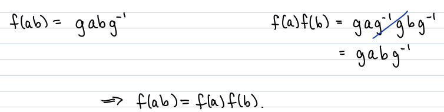

1. Define * on $\mathbb{R}$ by
   $$a*b=a+2b-ab$$

identity? Solve $a*e=a$ for e.

$$\begin{equation}\label{pp1}
\begin{split}
a+2e-ae=a &\Rightarrow 2e-ae=0\\
&\Rightarrow e(2-a)=0\\
&\Rightarrow e=0
\end{split}
\end{equation}$$

Check if for $e=0$, $e*a=a$:
$$e*a=0*a=0+2a-0\cdot a=2a\ne a$$

Since $e*a\ne a$ when $e=0$, there is no identity element.

6. $\alpha =(3714)$, $\beta=(123)$, $\rho=(24135)$ in $S_7$.

$$\begin{equation}\label{pp6}
\begin{split}
\alpha^{-1}\beta &= (3714)^{-1}(123)\\
&= (4173)(123)\\
&= (124)(37)
\end{split}
\end{equation}$$

# W6D17: Feb. 11th, 2022

MIDTERM!!!